# Exercise Classification using Wearable Device

Chaoping Guo

February 20, 2016

## Overview

This project uses data collected from accelerometers on the belt, forearm, arm, and dumbell of 6 participants and tries to fit a model to determine how a barbell lift is performed.

## Data Source and Preprocessing

Training data set pml-training.csv and test data set pml-testing.csv are downloaded to R working directory.

```r
training = read.csv('pml-training.csv')
test = read.csv('pml-testing.csv')
```

We will only use the variables that are complete:

```r
completeCheck = function(x){
  if(sum(is.na(x) | x == "")) return(F) else return(T)
}
complete.variables = apply(test, 2, completeCheck)
test = test[,complete.variables]
training = training[,complete.variables]
test$X = test$cvtd_timestamp = test$new_window = NULL
training$X = training$cvtd_timestamp = training$new_window = NULL
```

## Exploratory Data Analysis

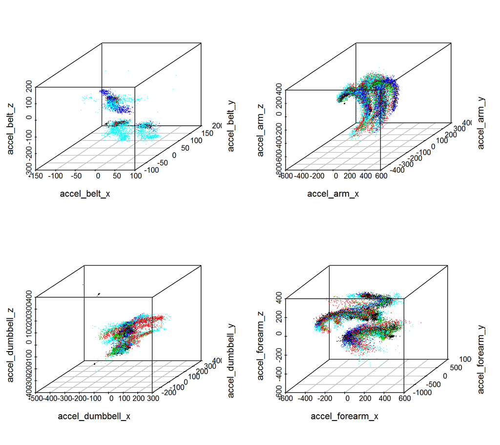

```r
library(scatterplot3d)
par(mfrow = c(2,2))
with(training, scatterplot3d(accel_belt_x,accel_belt_y,accel_belt_z, color = as.numeric(classe), pch = 16, cex.symbols = 0.2))
with(training, scatterplot3d(accel_arm_x,accel_arm_y,accel_arm_z, color = as.numeric(classe), pch = 16, cex.symbols = 0.2))
with(training, scatterplot3d(accel_dumbbell_x,accel_dumbbell_y,accel_dumbbell_z, color = as.numeric(classe), pch = 16, cex.symbols = 0.2))
with(training, scatterplot3d(accel_forearm_x,accel_forearm_y,accel_forearm_z, color = as.numeric(classe), pch = 16, cex.symbols = 0.2))
```

## Model Fitting and Cross Validation

First we use the data to train an SVM, and check it’s in-sample error rate:

```r
library(e1071)
model = svm(classe~., data = training)
error.in = mean(predict(model)!=training$classe)
```

The in-sample error rate is 4.12%, and we expect the out-of-sample error rate to be with lower accuracy than this.

```r
set.seed(123)
n.obs = nrow(training) ## Number of observations
shuffle = sample(n.obs) ## Reorder the training set
cv.error.rate = vector(mode = "numeric", length = 10)
for(i in 1:10){
  fold.train.index = shuffle[round(((n.obs/10)*(i-1))):round(((n.obs/10)*i))]
  cv.model = svm(classe~., data = training[fold.train.index,])
  cv.error.rate[i] = mean(predict(cv.model, newdata = training[-fold.train.index,])!=training[-fold.train.index,]$classe)
}
```

This gives an average cross-validate error rate of 15.69%, the test set error rate should also be close to this.

## Predict on the test set:

```r
result = predict(model, newdata = test)
write.table(result, 'Result.txt', sep = ",")
```